# Introduction to Statistical Learning: Lab Chapter 2

### Basic Commands

Use `c()` to create a vector:

```r
x <- c(1, 3, 2, 5)
```

Use `<-` or `=` to save content to an object:

```r
x = c(1, 6, 2)
y <- c(1, 4, 3)
```

Use `length()` to check the length of vector:

```r
length(x)
```

```
[1] 3
```

```r
length(y)
```

```
[1] 3
```

Adding two vectors of similar length will add the elements in the first vector to the respective elements in the second vector:

```r
x + y
```

```
[1]  2 10  5
```

Use `ls()` to look at a list of all objects in the current working environment:

```r
ls()
```

```
[1] "A" "f" "x" "y"
```

Use `rm()` to delete any elements in the working environment:

```r
rm(x, y)
ls()
```

```
[1] "A" "f"
```

Use `rm()` with `ls()` to remove all objects at once:

```r
rm(list=ls())
```

Use `matrix()` to create a matrix of numbers:

```r
x <- matrix(data = c(1,2,3,4), nrow = 2, ncol = 2)
```

Use `sqrt` to return the square root of each element in a vector or matrix:

```r
sqrt(x)
```

```
         [,1]     [,2]
[1,] 1.000000 1.732051
[2,] 1.414214 2.000000
```

Use `rnorm()` to generate a vector of random normal variables:

```r
x <- rnorm(n = 10)
y <- x + rnorm(n = 10, mean = 50, sd = 0.1)
```

Use `cor()` to compute the correlation between two vectors:

```r
cor(x, y)
```

```
[1] 0.9965877
```

Use `set.seed()` to set the seed for random number generators. This ensures code is reproducible:

```r
set.seed(4)
```

Use `mean()` , `var()` , and `sd()` to compute the mean, variance and standard deviation of a vector respectively:

```r
mean(x)
```

```
[1] 0.05669341
```

```r
var(x)
```

```
[1] 1.705616
```

```r
sd(x)
```

```
[1] 1.305992
```

### Graphics

Use the `plot()` function as the basic way to produce plots in R:

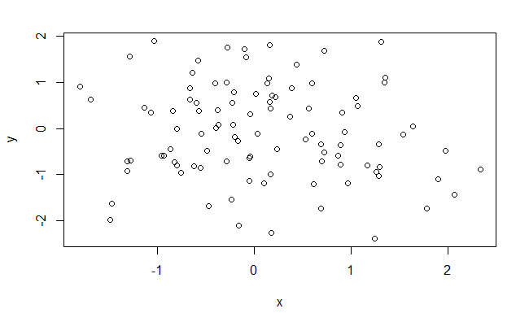

```r
x <- rnorm(100)
y <- rnorm(100)
plot(x, y)
```

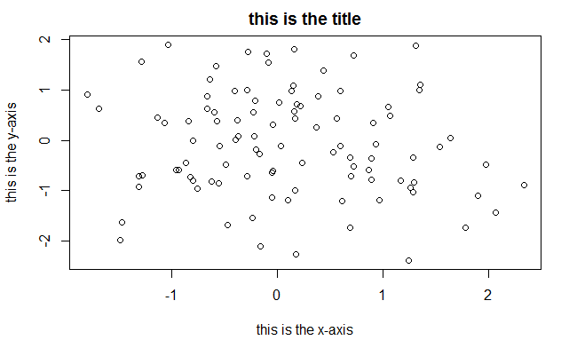

```r
plot(x, y, xlab = "this is the x-axis", ylab = "this is the y-axis", main = "this is the title")
```

Use `pdf()` or `jpeg()` to save plots to file:

```r
pdf("Figure.pdf")
plot(x, y)
dev.off()
```

The function `dev.off()` indicates to R that we are done with the plot we are saving to file.

Use `seq(a, b)` to create a sequence of numbers between `a` and `b`:

```r
x <- seq(1, 10)
x
```

```
 [1]  1  2  3  4  5  6  7  8  9 10
```

USe `contour()` to create a contour plot representing 3-dimensional data:

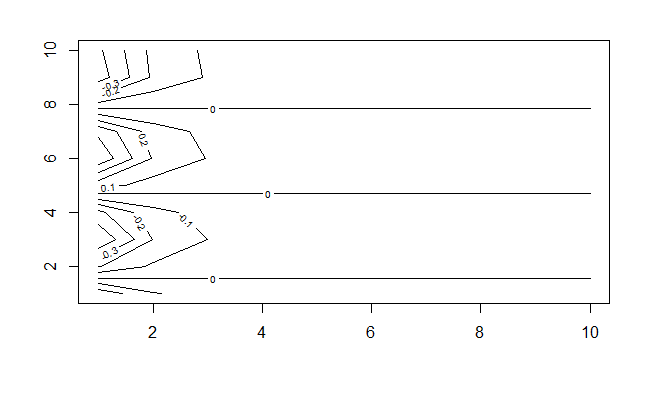

```r
y <- x
f <- outer(x, y, function(x, y) cos(y) / (1 + x ^ 2))
contour(x, y, f)
```

Use `image()` to create a heatmap in base R:

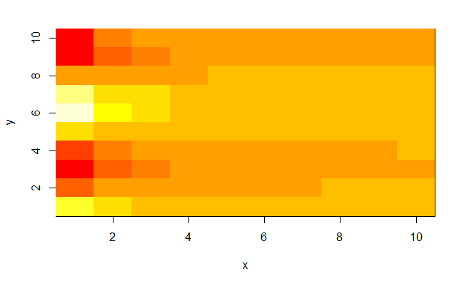

```r
image(x, y, f)
```

Use `persp()` to create a 3-dimensional plot in base R:

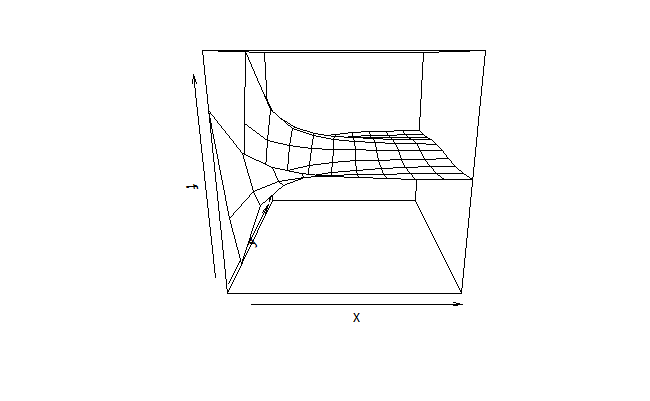

```r
persp(x, y, f)
```

### Indexing Data

Given a matrix `A`:

```r
A <- matrix(1:16, 4, 4)
```

Use `A[2,3]` to select the element in row 2 column 3 of the matrix:

```r
A[2,3]
```

```
[1] 10
```

Use `A[1, ]` to select all elements in row 1 of the matrix:

```r
A[1, ]
```

```
[1]  1  5  9 13
```

Use a `-` sign in the index to tell R to keep all elements except those indicated in the index:

```r
A[-1, ]
```

```
     [,1] [,2] [,3] [,4]
[1,]    2    6   10   14
[2,]    3    7   11   15
[3,]    4    8   12   16
```

Use `dim()` to output the number of rows and columns of a matrix:

```r
dim(A)
```

```
[1] 4 4
```

### Loading Data

This section contains mostly unused base R commands.

### Additional Graphical and Numerical Summaries

Use `pairs()` to craete a scatterplot matrix for every pair of data in a given data set.

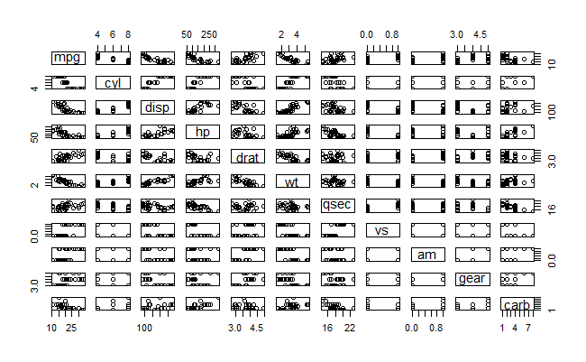

```r
pairs(mtcars)
```

Use `identify()` to make base R plots more interactive enabing one to print the value of a variable of interest by clicking it on a plot.

Use `summary()` to produce a numerical summary of each variable in a particular data set:

```r
summary(mtcars)
```

```
      mpg             cyl             disp             hp             drat             wt             qsec
 Min.   :10.40   Min.   :4.000   Min.   : 71.1   Min.   : 52.0   Min.   :2.760   Min.   :1.513   Min.   :14.50
 1st Qu.:15.43   1st Qu.:4.000   1st Qu.:120.8   1st Qu.: 96.5   1st Qu.:3.080   1st Qu.:2.581   1st Qu.:16.89
 Median :19.20   Median :6.000   Median :196.3   Median :123.0   Median :3.695   Median :3.325   Median :17.71
 Mean   :20.09   Mean   :6.188   Mean   :230.7   Mean   :146.7   Mean   :3.597   Mean   :3.217   Mean   :17.85
 3rd Qu.:22.80   3rd Qu.:8.000   3rd Qu.:326.0   3rd Qu.:180.0   3rd Qu.:3.920   3rd Qu.:3.610   3rd Qu.:18.90
 Max.   :33.90   Max.   :8.000   Max.   :472.0   Max.   :335.0   Max.   :4.930   Max.   :5.424   Max.   :22.90
       vs               am              gear            carb
 Min.   :0.0000   Min.   :0.0000   Min.   :3.000   Min.   :1.000
 1st Qu.:0.0000   1st Qu.:0.0000   1st Qu.:3.000   1st Qu.:2.000
 Median :0.0000   Median :0.0000   Median :4.000   Median :2.000
 Mean   :0.4375   Mean   :0.4062   Mean   :3.688   Mean   :2.812
 3rd Qu.:1.0000   3rd Qu.:1.0000   3rd Qu.:4.000   3rd Qu.:4.000
 Max.   :1.0000   Max.   :1.0000   Max.   :5.000   Max.   :8.000
```

Use `q()` to quite R.